# Chapter 7 Homework

AP

1/30/2022

## Question 1

A

## Question 2

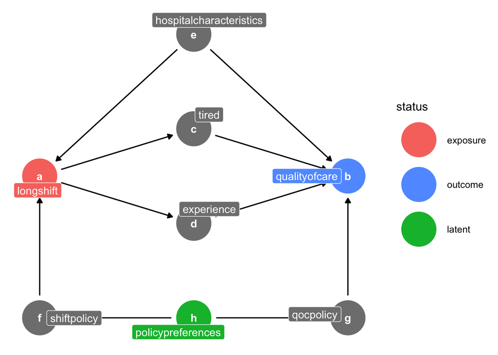

## Question 3

Treatment: School Funding; Outcome: Achievement

teacher quality, parent’s income, school educational resources, education policy, intelligence, motivation, community demographics, community monetary resources, community engagement, past years’ test scores, tax laws, supplemental resources

Teacher quality can impact achievement directly and also school funding indirectly (through past years’ test scores). Parent’s income can impact school funding directly, and achievement indirectly through supplemental resources.

We should pay extra attention to these because they are alternative explanations for our research question.

First diagram:

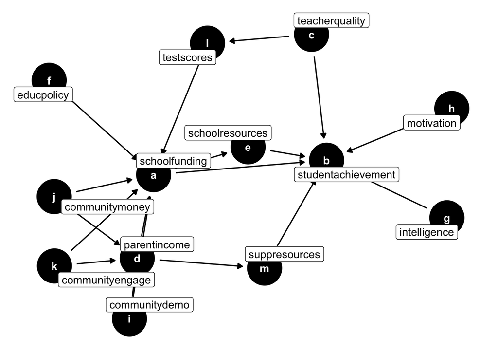

Simplified diagram:

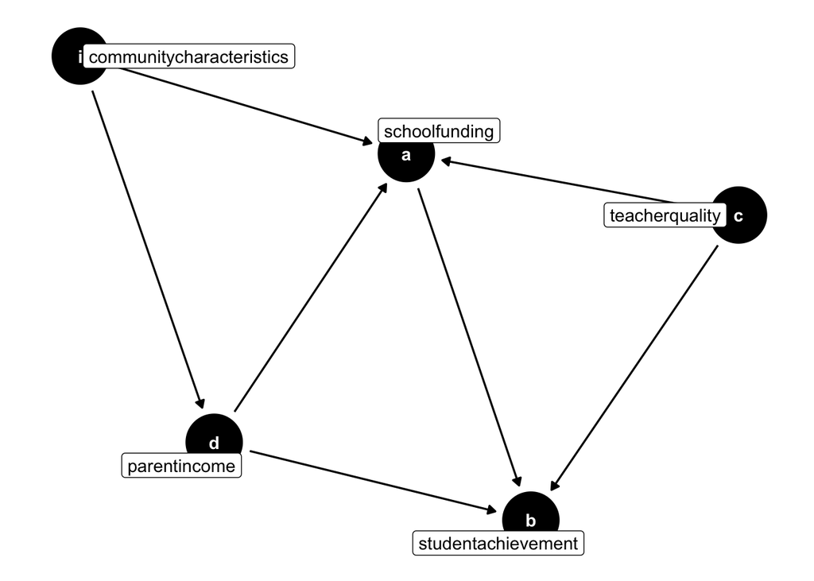

## Question 4

Unimportance: If the arrows coming in or out of a variable are likely to be tiny effects, you can probably delete it.

Redundancy: If variables have arrows coming and going from the same place, we can probably combine them into one.

Mediators: If a variable is only on a graph as a pathway between two other variables, we can probably take it off.

Irrelevance: If a variable is important to the DGP but irrelevant to the specific research question we’re asking, we can probably ignore it in the diagram.

## Question 5

You can introduce time into the diagram.

## Question 6

Cause: Parenting style

Outcome: Child’s income

Other relevant variables: Parent’s education, parent’s income, child’s education, neighborhood characteristics, race-ethnicity

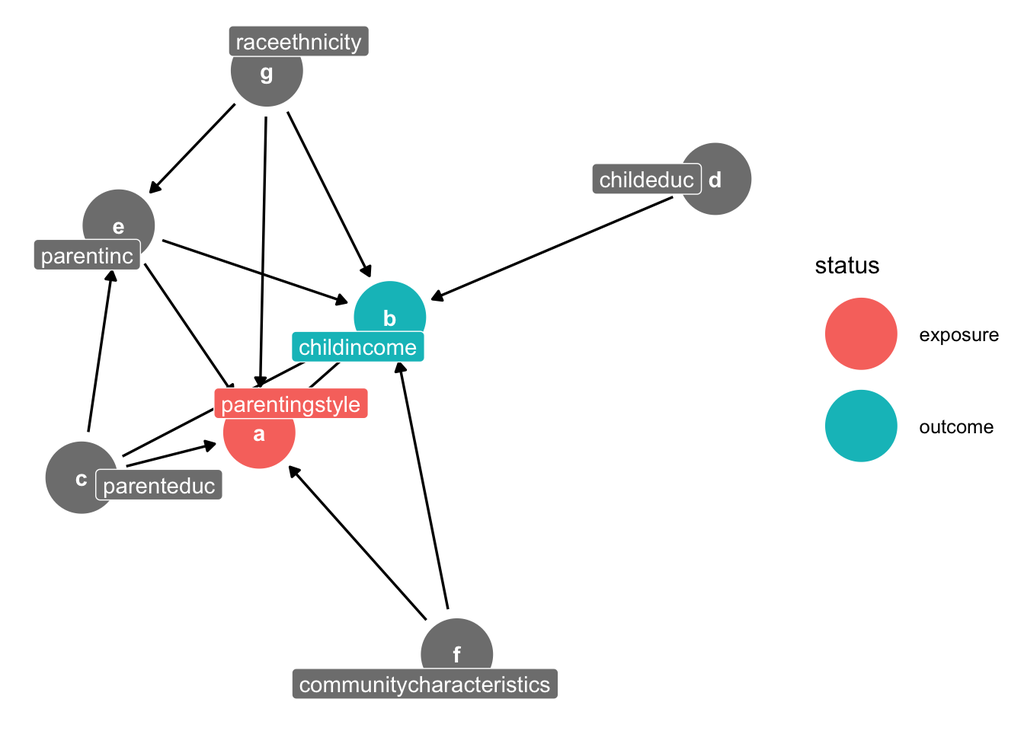

```r
q6dag <- dagify(
  b ~ a + c + d + e + f + g,
  a ~ c + e + f + g,
  e ~ c + g,
  labels = c(a = "parentingstyle",
             b = "childincome",
             c = "parenteduc",
             d = "childeduc",
             e = "parentinc",
             f = "communitycharacteristics",
             g = "raceethnicity"),
  exposure = "a",
  outcome = "b"
)

set.seed(11111)
ggdag_status(q6dag, use_labels = "label") + theme_dag()
```

## Question 7

PastMotivation $\rightarrow$ PastAchievement $\rightarrow$ Motivation $\rightarrow$ Achievement